# Music Data Analysis Vignette

## Introduction

This vignette shows how to use the `musicDataAnalysis` package. The package helps clean, summarize, and visualize the Top Spotify Songs 2023 dataset. The goal is to understand patterns in music popularity using streams and audio features such as energy, danceability, and bpm.

## Load the package and sample data

```r
library(musicDataAnalysis)

spotify_sample <- load_spotify_sample()
head(spotify_sample)
```

```
#>                            track_name       artist_name   streams energy
#> 1 Seven (feat. Latto) (Explicit Ver.)  Latto, Jung Kook 141381703     83
#> 2                                LALA       Myke Towers 133716286     74
#> 3                             vampire    Olivia Rodrigo 140003974     53
#> 4                        Cruel Summer      Taylor Swift 800840817     72
#> 5                      WHERE SHE GOES         Bad Bunny 303236322     80
#> 6                            Sprinter Dave, Central Cee 183706234     58
#>   danceability bpm
#> 1           80 125
#> 2           71  92
#> 3           51 138
#> 4           55 170
#> 5           65 144
#> 6           92 141
```

The included sample data is already cleaned. It has track names, artist names, streams, energy, danceability, and bpm.

## Summary statistics

```r
summarize_music(spotify_sample)
```

```
#>   avg_streams correlate_energy correlate_dance correlate_bpm
#> 1   514137425      -0.02605149      -0.1054569  -0.002437908
```

This output gives the average number of streams and the correlations between streams and the audio features.

```r
summarize_features(spotify_sample)
```

```
#>        feature      mean       sd min median max
#> 1       energy  64.27416 16.55852   9     66  97
#> 2 danceability  66.98424 14.63128  23     69  96
#> 3          bpm 122.55357 28.06960  65    121 206
```

This output gives basic statistics for energy, danceability, and bpm.

## Artist analysis

```r
top_artists(spotify_sample, n = 10)
```

```
#>        artist_name total_streams
#> 1       The Weeknd   14185552870
#> 2     Taylor Swift   14053658300
#> 3       Ed Sheeran   13908947204
#> 4     Harry Styles   11608645649
#> 5        Bad Bunny    9997799607
#> 6   Olivia Rodrigo    7442148916
#> 7           Eminem    6183805596
#> 8       Bruno Mars    5846920599
#> 9   Arctic Monkeys    5569806731
#> 10 Imagine Dragons    5272484650
```

This shows the artists with the highest total streams in the cleaned data.

```r
artist_summary(spotify_sample, "Taylor Swift")
```

```
#>   total_tracks total_streams avg_energy avg_danceability avg_bpm    top_song
#> 1           38   14630378183   55.15789         59.97368     124 Blank Space
```

This gives a short summary for one selected artist.

## Visualizations

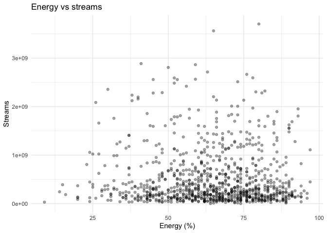

```r
plots <- plot_music(spotify_sample)
plots$scatter_energy_streams
```

The scatterplot helps show the relationship between energy and streams.

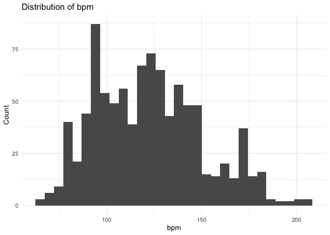

```r
plot_feature_distribution(spotify_sample, "bpm")
```

This plot shows the distribution of bpm across songs.

## Conclusion

This package gives users a simple way to clean Spotify data, calculate basic summaries, and create useful plots. These tools make it easier to explore what characteristics appear in popular songs.